# PRAC2. Análisis de supervivencia de pasajeros en el Titanic

# Factorización

Inicialmente se busca el número de valores únicos que existen en cada variable.

```r
# Primero, comprobamos qué variables son las que debemos binarizar
apply(df2, 2, function(x) length(unique(x)))
```

```
## PassengerId    Survived      Pclass        Name         Sex         Age
##         888           2           3         888           2          71
##       SibSp       Parch        Fare
##           7           7         236
```

Se transforma la variable sex

```r
# Y binarizamos la variable 'sex', para registrarla en vez de como 'male' y 'female', como (0,1)

df2 <- transform(df2, Sex = ifelse(Sex== "male", 0, 1))

# Después de los cambios, analizamos la nueva estructura del conjunto de datos
str(df2)
```

```
## 'data.frame':    888 obs. of  9 variables:
##  $ PassengerId: int  1 2 3 4 5 6 7 8 9 10 ...
##  $ Survived   : int  0 1 1 1 0 0 0 0 1 1 ...
##  $ Pclass     : int  3 1 3 1 3 3 1 3 3 2 ...
##  $ Name       : chr  "Braund, Mr. Owen Harris" "Cumings, Mrs. John Bradley (Florence Briggs Thayer)" "Heikkinen, Miss. Laina" "Futrelle, Mrs. Jacques Heath (Lily May Peel)" ...
##  $ Sex        : num  0 1 1 1 0 0 0 0 1 1 ...
##  $ Age        : int  22 38 26 35 35 29 54 2 27 14 ...
##  $ SibSp      : int  1 1 0 1 0 0 0 3 0 1 ...
##  $ Parch      : int  0 0 0 0 0 0 0 1 2 0 ...
##  $ Fare       : num  7.25 71.28 7.92 53.1 8.05 ...
```

Creación de la variable Fam. Esta variable indica si el pasajero tiene familiares a bordo del barco o no.

```r
# El siguiente paso es crear una nueva variable ('Fam') a partir de la combinación de las variables SibSp y Parch. Esta variable nos indica si el sujeto tiene (1) o no tiene (0) familia.
df3 <- transform(df2, Fam = ifelse(SibSp==0 & Parch ==0, 0, 1))

# Comprobamos que la variable 'Fam' se ha creado correctamente, tomando valor 1 si el sujeto tiene algún familiar (si SibSp o Parch es distinto de cero) y valor 0 si no tienen ninguno (SibSp y Parch son iguales a cero).

summary(df3$Fam)
```

```
##    Min. 1st Qu.  Median    Mean 3rd Qu.    Max.
##  0.0000  0.0000  0.0000  0.3975  1.0000  1.0000
```

```r
unique(df3$Fam[df3$SibSp==0 & df3$Parch == 0])
```

```
## [1] 0
```

```r
# Habiendo comprobado que hemos creado con éxito la variable Fam, vamos a eliminar las variables 'SibSp' y 'Parch', ya que el contenido de interés analítico en este caso se encuentra recogido en la nueva variable 'Fam'.

borrar <- c("SibSp","Parch")
df_final <- df3[ , !(names(df3) %in% borrar)]

# Y comprobamos que se han borrado correctamente:

head(df_final)
```

|  | PassengerId | Survived | Pclass | Name | Sex | Age | Fare | Fam |
| --- | --- | --- | --- | --- | --- | --- | --- | --- |
| 1 | 1 | 0 | 3 | Braund, Mr. Owen Harris | 0 | 22 | 7.25 | 1 |
| 2 | 2 | 1 | 1 | Cumings, Mrs. John Bradley (Florence Briggs Thayer) | 1 | 38 | 71.28 | 1 |
| 3 | 3 | 1 | 3 | Heikkinen, Miss. Laina | 1 | 26 | 7.92 | 0 |
| 4 | 4 | 1 | 1 | Futrelle, Mrs. Jacques Heath (Lily May Peel) | 1 | 35 | 53.10 | 1 |
| 5 | 5 | 0 | 3 | Allen, Mr. William Henry | 0 | 35 | 8.05 | 0 |
| 6 | 6 | 0 | 3 | Moran, Mr. James | 0 | 29 | 8.46 | 0 |

Factorización de las variables Survived, Pclass, Sex y Fam

```r
# Antes de exportar nuestros datos, vamos a factorizar las variables que lo requieran para evitar futuros conflictos.

str(df_final)
```

```
## 'data.frame':    888 obs. of  8 variables:
##  $ PassengerId: int  1 2 3 4 5 6 7 8 9 10 ...
##  $ Survived   : int  0 1 1 1 0 0 0 0 1 1 ...
##  $ Pclass     : int  3 1 3 1 3 3 1 3 3 2 ...
##  $ Name       : chr  "Braund, Mr. Owen Harris" "Cumings, Mrs. John Bradley (Florence Briggs Thayer)" "Heikkinen, Miss. Laina" "Futrelle, Mrs. Jacques Heath (Lily May Peel)" ...
##  $ Sex        : num  0 1 1 1 0 0 0 0 1 1 ...
##  $ Age        : int  22 38 26 35 35 29 54 2 27 14 ...
##  $ Fare       : num  7.25 71.28 7.92 53.1 8.05 ...
##  $ Fam        : num  1 1 0 1 0 0 0 1 1 1 ...
```

```r
# Vemos que las variables que no son leídas como factores son 'Survived', 'Pclass', 'Sex' y 'Fam', las factorizamos y nuestra base de datos queda lista para el análisis

cols<-c("Survived", "Pclass", "Sex", "Fam")
for (i in cols){
  df_final[,i] <- as.factor(df_final[,i])
}

str(df_final)
```

```
## 'data.frame':    888 obs. of  8 variables:
##  $ PassengerId: int  1 2 3 4 5 6 7 8 9 10 ...
##  $ Survived   : Factor w/ 2 levels "0","1": 1 2 2 2 1 1 1 1 2 2 ...
##  $ Pclass     : Factor w/ 3 levels "1","2","3": 3 1 3 1 3 3 1 3 3 2 ...
##  $ Name       : chr  "Braund, Mr. Owen Harris" "Cumings, Mrs. John Bradley (Florence Briggs Thayer)" "Heikkinen, Miss. Laina" "Futrelle, Mrs. Jacques Heath (Lily May Peel)" ...
##  $ Sex        : Factor w/ 2 levels "0","1": 1 2 2 2 1 1 1 1 2 2 ...
##  $ Age        : int  22 38 26 35 35 29 54 2 27 14 ...
##  $ Fare       : num  7.25 71.28 7.92 53.1 8.05 ...
##  $ Fam        : Factor w/ 2 levels "0","1": 2 2 1 2 1 1 1 2 2 2 ...
```

# Exportación de los datos

```r
write.csv(df_final, "Data Final.csv", row.names=FALSE)
```

# Análisis

## Estudio preliminar de variables

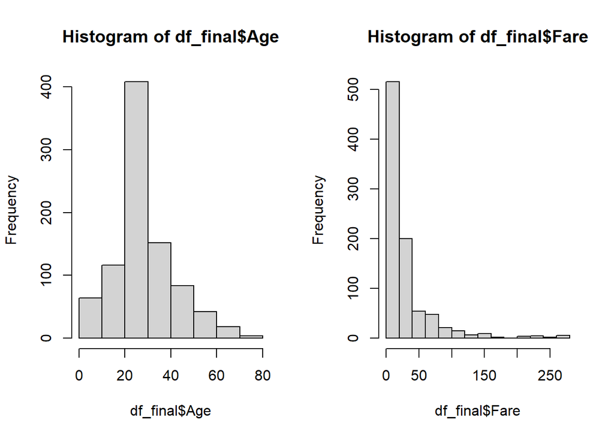

```r
# Antes de comenzar con el análisis, vamos a observar cómo se comportan las variables finales con las que trabajaremos. Usaremos primero histogramas para hacernos una primera idea.

par(mfrow=c(1,2))
hist(df_final$Age)
hist(df_final$Fare)
```

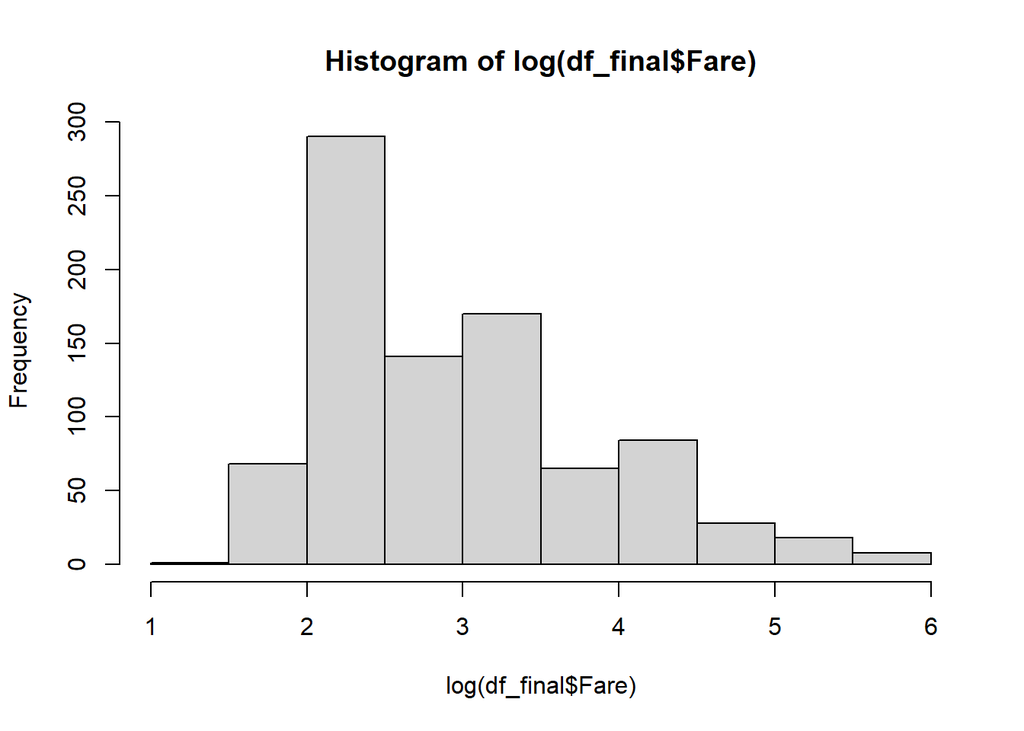

```r
# De la representación anterior, vemos que la variable 'Fare' (precio del billete) requeriría de una escala logarítmica para poder observar mejor cómo se comportan sus registros.

hist(log(df_final$Fare))
```

```r
# Hacemos una primera representación de las correlaciones entre variables para ir haciéndonos una idea de cómo se comportan los registros que tenemos.

vars <- df_final[, c("Survived", "Pclass", "Sex", "Age", "Fare", "Fam")]
```

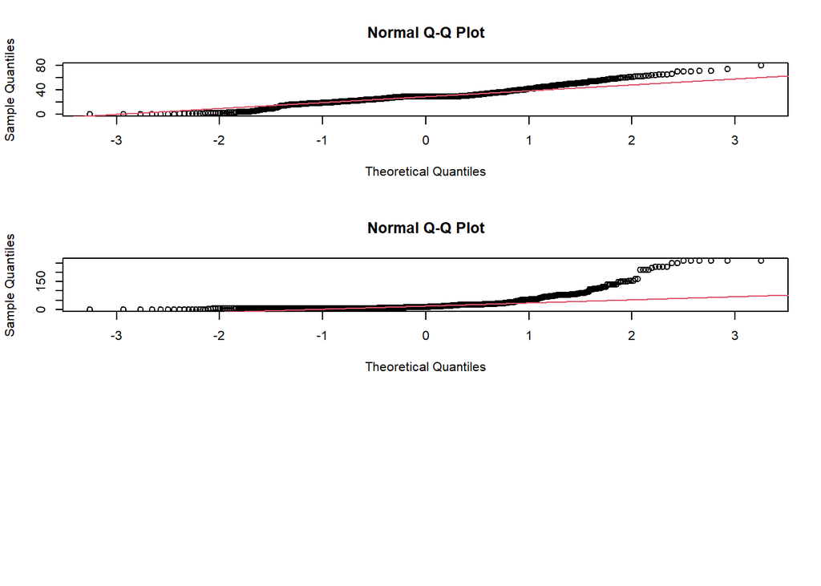

```r
#Análisis de la normalidad de Age
par(mfrow=c(3,1))
qqnorm(df_final$Age);qqline(df_final$Age,col=2)
qqnorm(df_final$Fare);qqline(df_final$Fare,col=2)
```

```r
# install.packages("GGally")

library(GGally)
```

```r
library(ggplot2)
```

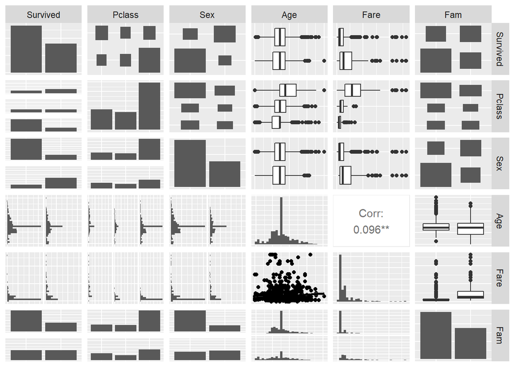

```r
ggpairs(vars, lower = list(continuous="smooth"), diag = list(continuous="barDiag"), axisLabels = "none")
```

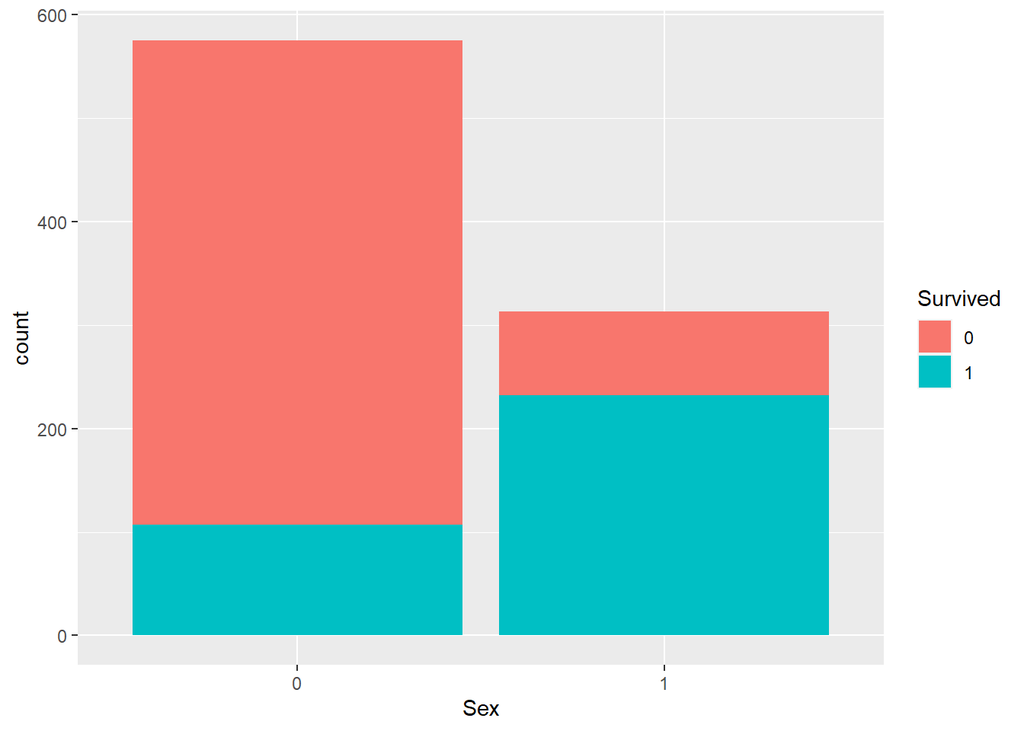

```r
# Graficamos algunas variables en función de survived, para observar tendencias en las relaciones y guiarnos para la construcción de nuestros análisis

library(ggplot2)
# install.packages("dplyr")
library(dplyr)
filas=dim(df_final)

# Empezamos por ver la relación entre el género y la supervivencia (Sex-Survival)

ggplot(data=df_final[1:filas,],aes(x=Sex,fill=Survived))+geom_bar()
```

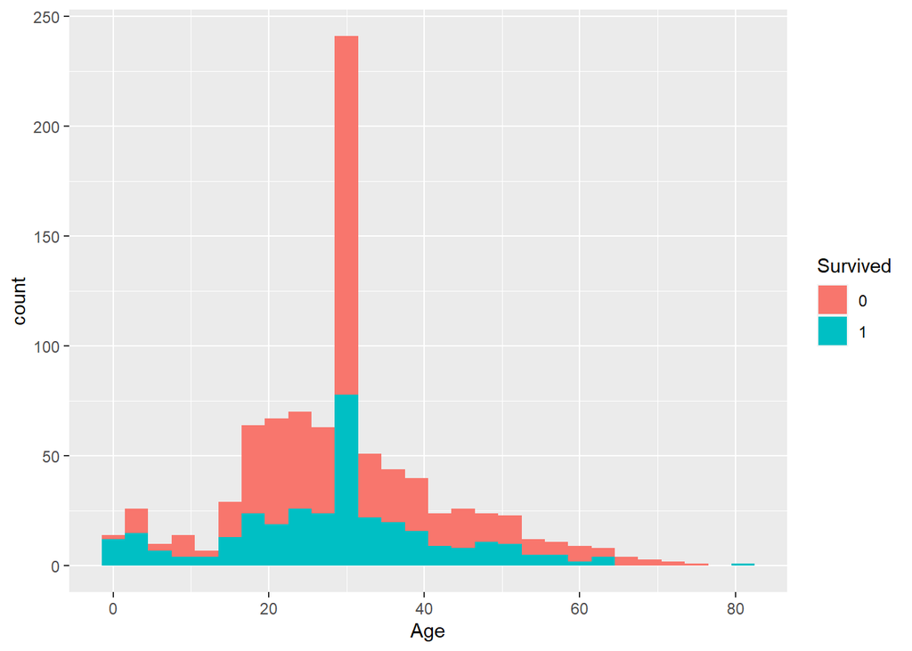

```r
# Y graficamos también la supervivencia en función de la edad

ggplot(data = df_final[!(is.na(df_final[1:filas,]$Age)),],aes(x=Age,fill=Survived))+geom_histogram(binwidth =3)
```

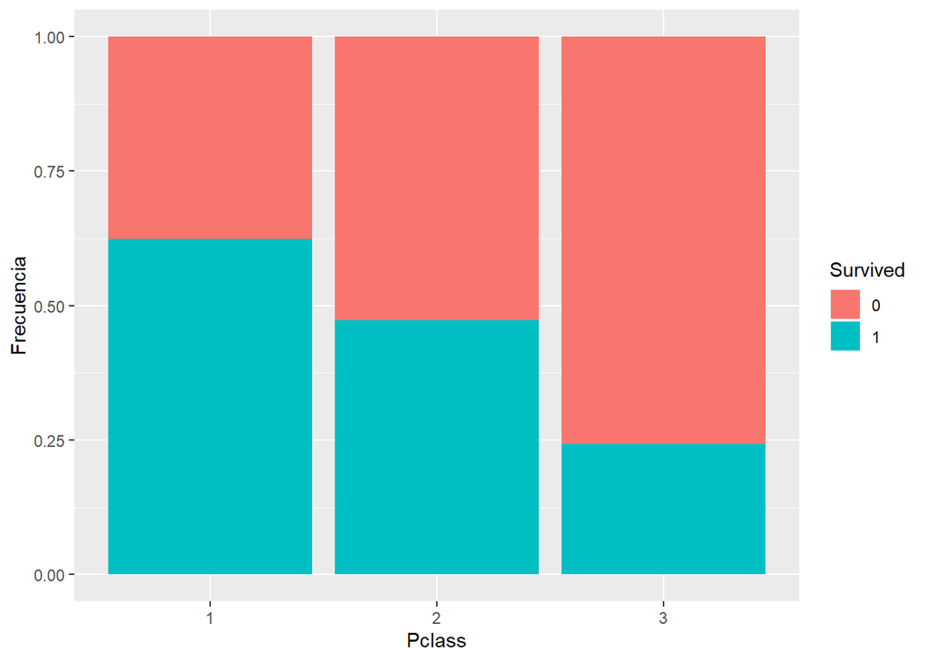

```r
# Probamos a continuación a graficar Survival en función de Pclass

ggplot(data = df_final[1:filas,],aes(x=Pclass,fill=Survived))+geom_bar(position="fill")+ylab("Frecuencia")
```

```r
# Obtenemos, además, una matriz de porcentajes de freccuencia. Vemos que la probabilidad de sobrevivir si el billete es de primera clase es de 62.44%, si es de segunda clase 47.28%, y si es de tercera clase 24,24%.

t<-table(df_final[1:filas,]$Pclass, df_final[1:filas,]$Survived)
for (i in 1:dim(t)[1]){
    t[i,]<-t[i,]/sum(t[i,])*100
}

t
```

```
##
##            0        1
##   1 37.55869 62.44131
##   2 52.71739 47.28261
##   3 75.76375 24.23625
```

## Estudio de hipótesis

### Hipótesis 1. Cuando uno paga más por un billete de primera, puede pensar que paga no solo por lujo sino por un aumeno de la seguridad. Comprobamos si efectivamente existe una correlación entre el precio del billete (Fare) y la supervivencia (Survived)

```r
# Comenzamos con el análisis de nuestro dataset, compuesto de tres partes:
# 1 - Correlación + regresión simple: ¿Existe una correlación entre pagar más por el billete y aumentar tu probabilidad de sobrevivir? ¿Cuánto afecta el precio del billete a la probabilidad de sobrevivir?
# 2 - Regresión: ¿Afectaron las características identitarias de una persona (su edad, género, clase y si tiene o no familia) a su probabilidad de sobrevivir?
# 3 - Métodos de asociación. Dadas las diferentes combinaciones de valores para cada registro, ¿es posible establecer unas reglas en forma de condicional que representen la probabilidad de diferentes darse determinadas combinaciones de eventos?


# CORRELACIÓN

# Cuando uno paga más por un billete de primera, puede pensar que paga no solo por lujo sino por un aumeno de la seguridad. Comprobamos si efectivamente existe una correlación entre el precio del billete (Fare) y la supervivencia (Survived)

# Con este fin, registramos la variable Survived como numérica

df_final$Survived_numeric <- as.numeric(df_final$Survived)
```

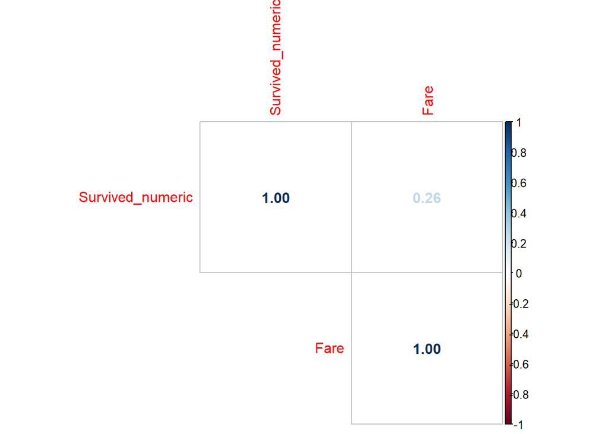

```r
var.cor <- select(df_final, Survived_numeric, Fare)
correlacion1 <- cor(var.cor, method = "pearson")
# install.packages("corrplot")
library(corrplot)
corrplot(correlacion1, method = "number", type = "upper")
```

```r
# Realizamos la regresión simple que evalúa de forma más precisa de qué manera interactúan estas dos variables
regresion_simple <- glm(formula = Survived~Fare, data = df_final, family = binomial)
summary(regresion_simple)
```

```
##
## Call:
## glm(formula = Survived ~ Fare, family = binomial, data = df_final)
##
## Deviance Residuals:
##     Min       1Q   Median       3Q      Max
## -2.4899  -0.8885  -0.8531   1.3458   1.5941
##
## Coefficients:
##              Estimate Std. Error z value Pr(>|z|)
## (Intercept) -0.941125   0.095192  -9.887  < 2e-16 ***
## Fare         0.015189   0.002236   6.794 1.09e-11 ***
## ---
## Signif. codes:  0 '***' 0.001 '**' 0.01 '*' 0.05 '.' 0.1 ' ' 1
##
## (Dispersion parameter for binomial family taken to be 1)
##
##     Null deviance: 1180.9  on 887  degrees of freedom
## Residual deviance: 1117.6  on 886  degrees of freedom
## AIC: 1121.6
##
## Number of Fisher Scoring iterations: 4
```

```r
# install.packages("pROC")

library(pROC)
probabilidad_bajo=predict(regresion_simple, df_final, type="response")
r=roc(df_final$Survived, probabilidad_bajo, data = df_final)
```

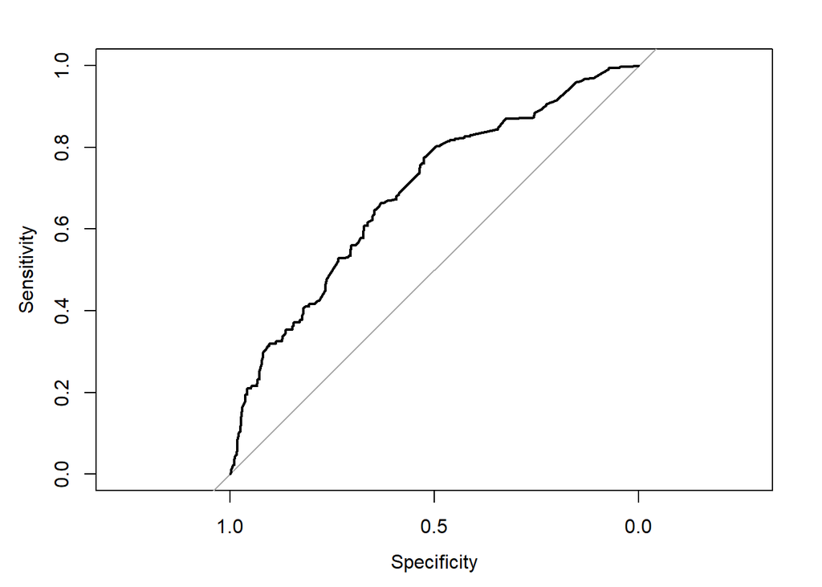

```r
plot(r)
```

```r
auc(r)
```

```
## Area under the curve: 0.6894
```

```r
# Como el área bajo la curva está entre 0.6 y 0.8, podemos considerar que el modelo discrimina de manera adecuada.
```

### Hipótesis 2. Realizamos una regresión logística múltiple para ver de qué manera los rasgos identitarios de la persona afectan a sus probabilidades de supervivencia. Lo evaluamos con las variables: sex, age, pclass (proxy de la clase social) y Fam.

```r
# PARTE 2 - Realizamos una regresión logística múltiple para ver de qué manera los rasgos identitarios de la persona afectan a sus probabilidades de supervivencia. Lo evaluamos con las variables: sex, age, pclass (proxy de la clase social) y Fam.

regresion_multiple <- glm(formula = Survived~Age+Sex+Pclass+Fam, data = df_final, family = binomial)
summary(regresion_multiple)
```

```
##
## Call:
## glm(formula = Survived ~ Age + Sex + Pclass + Fam, family = binomial,
##     data = df_final)
##
## Deviance Residuals:
##     Min       1Q   Median       3Q      Max
## -2.6326  -0.6498  -0.4265   0.6237   2.4271
##
## Coefficients:
##              Estimate Std. Error z value Pr(>|z|)
## (Intercept)  0.939319   0.352065   2.668  0.00763 **
## Age         -0.033740   0.007533  -4.479 7.50e-06 ***
## Sex1         2.639080   0.194296  13.583  < 2e-16 ***
## Pclass2     -1.095095   0.259563  -4.219 2.45e-05 ***
## Pclass3     -2.312422   0.244644  -9.452  < 2e-16 ***
## Fam1        -0.077492   0.188340  -0.411  0.68074
## ---
## Signif. codes:  0 '***' 0.001 '**' 0.01 '*' 0.05 '.' 0.1 ' ' 1
##
## (Dispersion parameter for binomial family taken to be 1)
##
##     Null deviance: 1180.89  on 887  degrees of freedom
## Residual deviance:  801.61  on 882  degrees of freedom
## AIC: 813.61
##
## Number of Fisher Scoring iterations: 5
```

```r
library(pROC)

probabilidad_bajo=predict(regresion_multiple, df_final, type="response")
r=roc(df_final$Survived, probabilidad_bajo, data = df_final)
```

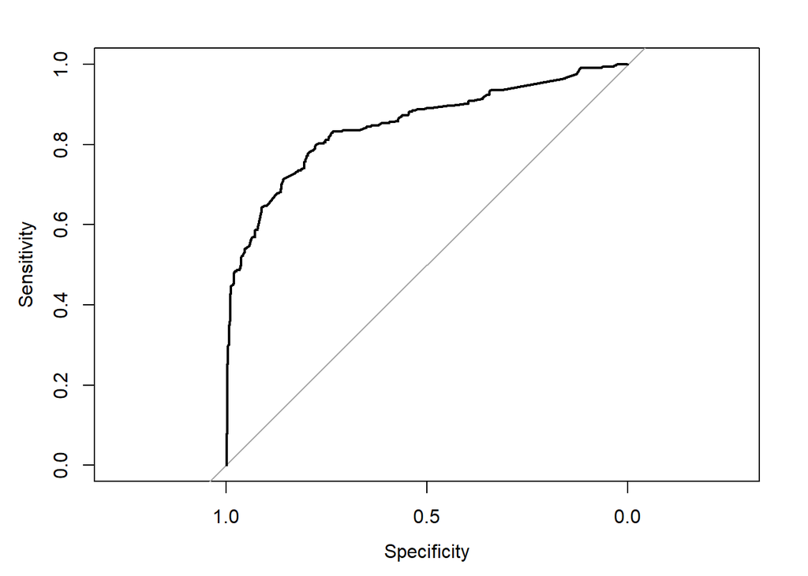

```r
plot(r)
```

```r
auc(r)
```

```
## Area under the curve: 0.8479
```

```r
# Como el área bajo la curva está entre 0.8 y 0.9, se estima que el modelo discrimina de forma excelente.

# Vemos que la variable que no afecta de forma significativa es Fam, por lo tanto vamos a realizar de nuevo la regresión sin considerar esta variable para ver si podemos ajustar aún más nuestros resultados
```

```r
regresion_multiple2 <- glm(formula = Survived~Age+Sex+Pclass, data = df_final, family = binomial)
summary(regresion_multiple2)
```

```
##
## Call:
## glm(formula = Survived ~ Age + Sex + Pclass, family = binomial,
##     data = df_final)
##
## Deviance Residuals:
##     Min       1Q   Median       3Q      Max
## -2.6342  -0.6666  -0.4225   0.6282   2.4309
##
## Coefficients:
##              Estimate Std. Error z value Pr(>|z|)
## (Intercept)  0.886501   0.327553   2.706   0.0068 **
## Age         -0.033123   0.007373  -4.493 7.04e-06 ***
## Sex1         2.617564   0.186685  14.021  < 2e-16 ***
## Pclass2     -1.085267   0.258301  -4.202 2.65e-05 ***
## Pclass3     -2.297093   0.241673  -9.505  < 2e-16 ***
## ---
## Signif. codes:  0 '***' 0.001 '**' 0.01 '*' 0.05 '.' 0.1 ' ' 1
##
## (Dispersion parameter for binomial family taken to be 1)
##
##     Null deviance: 1180.89  on 887  degrees of freedom
## Residual deviance:  801.78  on 883  degrees of freedom
## AIC: 811.78
##
## Number of Fisher Scoring iterations: 5
```

```r
library(pROC)

probabilidad_bajo=predict(regresion_multiple2, df_final, type="response")
r=roc(df_final$Survived, probabilidad_bajo, data = df_final)
```

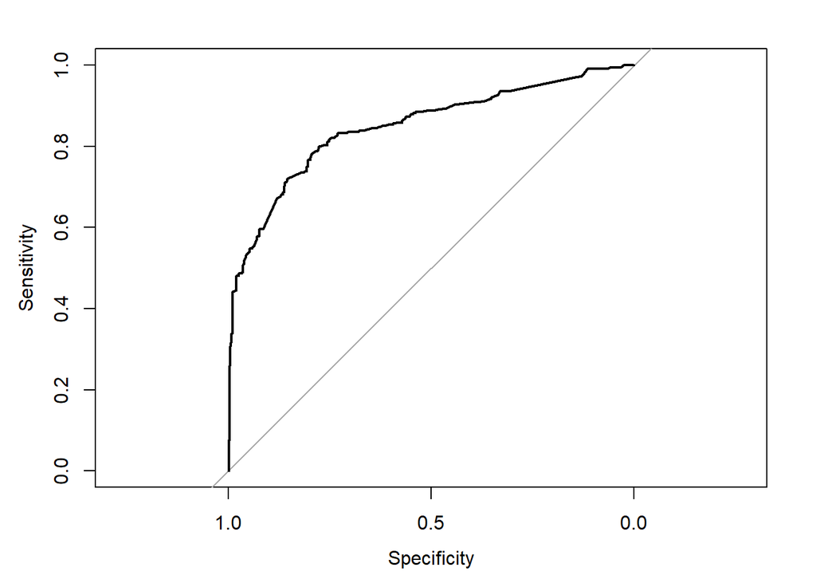

```r
plot(r)
```

```r
auc(r)
```

```
## Area under the curve: 0.8474
```

```r
# Vemos que el modelo no mejora significativamente
```

## Análisis mediante reglas de asociación

```r
# PARTE 3 MÉTODOS DE ASOCIACIÓN

# En esta tercera parte vamos a obtener reglas de asociacion a partir de una selección de variables categóricas del dataset.
# Dichas reglas nos ayudarán a comprender cómo la información del data set se relaciona entre si.

#install.packages("arules")
library(arules)
df_final1<- select(df_final, "Fam", "Sex", "Pclass", "Survived")
titanic_rules <- apriori(df_final1, parameter = list(support = 0.01, confidence = 0.5))
```

```
## Apriori
##
## Parameter specification:
##  confidence minval smax arem  aval originalSupport maxtime support minlen
##         0.5    0.1    1 none FALSE            TRUE       5    0.01      1
##  maxlen target  ext
##      10  rules TRUE
##
## Algorithmic control:
##  filter tree heap memopt load sort verbose
##     0.1 TRUE TRUE  FALSE TRUE    2    TRUE
##
## Absolute minimum support count: 8
##
## set item appearances ...[0 item(s)] done [0.00s].
## set transactions ...[9 item(s), 888 transaction(s)] done [0.00s].
## sorting and recoding items ... [9 item(s)] done [0.00s].
## creating transaction tree ... done [0.00s].
## checking subsets of size 1 2 3 4 done [0.00s].
## writing ... [122 rule(s)] done [0.00s].
## creating S4 object  ... done [0.00s].
```

```r
inspect(head(sort(titanic_rules, by = "confidence"), 5))
```

```
##     lhs                              rhs          support    confidence
## [1] {Fam=0, Pclass=1, Survived=0} => {Sex=0}      0.05630631 0.9803922
## [2] {Fam=0, Sex=1, Pclass=1}      => {Survived=1} 0.03603604 0.9696970
## [3] {Sex=1, Pclass=1}             => {Survived=1} 0.10135135 0.9677419
## [4] {Fam=1, Sex=1, Pclass=1}      => {Survived=1} 0.06531532 0.9666667
## [5] {Pclass=1, Survived=0}        => {Sex=0}      0.08671171 0.9625000
##     coverage   lift     count
## [1] 0.05743243 1.514066 50
## [2] 0.03716216 2.540091 32
## [3] 0.10472973 2.534970 90
## [4] 0.06756757 2.532153 58
## [5] 0.09009009 1.486435 77
```

```r
# Como vemos se ha generado un set de reglas con diferente soporte, confianza y lift.

# El soporte indica cuantas veces se han encontrado las reglas {lsh => rhs} en el dataset, cuanto más alto mejor.
# La confianza habla de la probabilidad de que {rhs} se de en función de {lhs}.
# El lift es un parámetro que nos indica cuánto de aleatoriedad hay en las reglas. Un lift de 1 o menos es que las reglas son
# completamente fruto del azar.
```

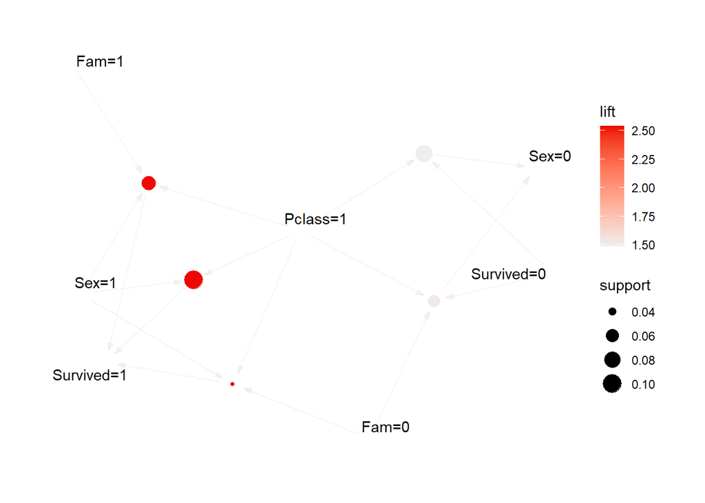

```r
# Representación visual
# install.packages("arulesViz")

library(arulesViz)
# Creamos un subconjunto de 5 reglas de entre todas las reglas posibles.
subrules <- head(sort(titanic_rules, by = "confidence"), 5)
plot(subrules, method="graph")
```

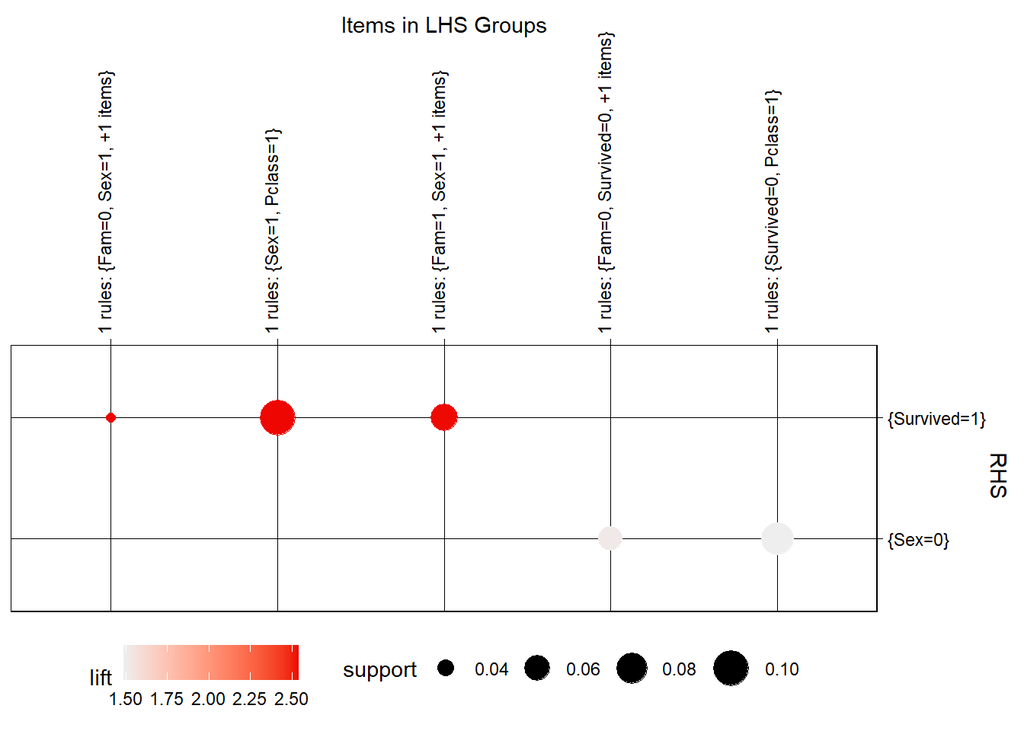

```r
plot(subrules, method = "grouped", control = list(k = 5))
```

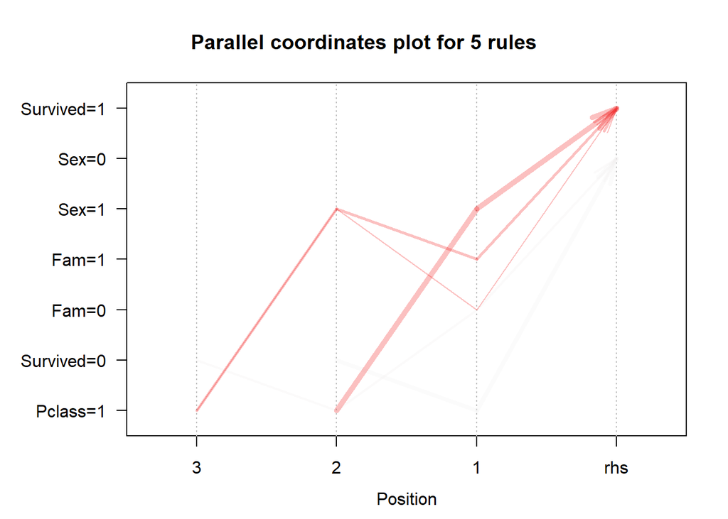

```r
plot(subrules, method="paracoord",  control=list(alpha=.5, reorder=FALSE))
```